# 213SymPy

## Matemática Simbólica com Python SymPy

Professor: Maykoll Rocha

Aula preparada para ser usada nas Faculdades Abertas da UFGD.

A biblioteca inclui estruturas polinomiais, entre outras coisas, mas o foco é o plot de polinômios. Começaremos mostrando algumas informações sobre como criar polinômios e introduzir uma mistura entre Matplotlib + SymPy, seguindo a documentação original. Também podemos apresentar isso com o LaTeX, que é uma linguagem para fazer essas apresentações.

Documentação SymPy: https://docs.sympy.org/latest/tutorials/intro-tutorial/preliminaries.html

Ciencia Promada: https://cienciaprogramada.com.br/category/sympy/

Drive Para o Jupyter Notebook: https://drive.google.com/file/d/1ZUgaMUk3v3ZfGbBbNShVb1RecQu3oGTH/view?usp=sharing

Instalar

```python
#!pip install sympy
```

```python
#!pip install sympy_plot_backends[all]
```

# Introdução

### Diferença entre SymPy e Math

A importação é básica; para baixar, utilize o tutorial do primeiro link (caso não esteja em um editor online ou que já venha com ele).

```python
import sympy as sy
import math as mt
```

```python
sy.__version__
```

```
'1.11.1'
```

```python
sy.init_printing(pretty_print=True,scale=1.0,
                    forecolor='Black', backcolor='White',
                 use_unicode =True)
```

```python
mt.sqrt(8)
```

$\displaystyle 2.82842712474619$

```python
sy.sqrt(8)
```

$\displaystyle 2 \sqrt{2}$

```python
sy.sqrt(8,evaluate=False)
```

$\displaystyle \sqrt{8}$

Percebe-se que a math é utilizada para obter o valor real, enquanto a sympy lida com seus símbolos.

### Definir Símbolos

Agora, vou mostrar como definir símbolos. Em uma função matemática, temos por exemplo x² + 1, onde "x" é um símbolo matemático. No SymPy, podemos criar símbolos simbólicos para fazer isso utilizando a função symbols.

```python
x, y = sy.symbols('x y')
```

Agora, "x" e "y" são símbolos, ou variáveis simbólicas, como preferir chamá-las.

Sim, podemos definir sequências de símbolos também, como $a_0, a_1,..., a_{n-1}$

```python
a1,a2,a3,a4,a5,a6,a7,a8,a9,a0= sy.symbols('a:10')
```

```python
a1,a2,a3,a4,a5,a6,a7,a8,a9,a0
```

$\displaystyle \left( a_{0}, \ a_{1}, \ a_{2}, \ a_{3}, \ a_{4}, \ a_{5}, \ a_{6}, \ a_{7}, \ a_{8}, \ a_{9}\right)$

Ou fazer uma definição alfanumerica a...z

```python
sy.symbols('a:z')
```

$\displaystyle \left( a, \ b, \ c, \ d, \ e, \ f, \ g, \ h, \ i, \ j, \ k, \ l, \ m, \ n, \ o, \ p, \ q, \ r, \ s, \ t, \ u, \ v, \ w, \ x, \ y, \ z\right)$

Caso queira representar uma fração, é necessário usar funções para isso. Pode-se utilizar sy.S('') ou sy.rational(numerador, denominador).

```python
a = 1/7
a
```

$\displaystyle 0.142857142857143$

```python
a = sy.Rational(1,5)
a
```

$\displaystyle \frac{1}{5}$

```python
b = sy.S('1/7')
b
```

$\displaystyle \frac{1}{7}$

```python
a+b
```

$\displaystyle \frac{12}{35}$

Podemos também representar alguns números especiais como $\pi$ (pi) e $e$ (euler):

```python
sy.pi
```

$\displaystyle \pi$

```python
sy.E
```

$\displaystyle e$

```python
sy.pi.evalf(10)
```

$\displaystyle 3.141592654$

```python
sy.sqrt(8).evalf(0)
```

$\displaystyle 3.0$

Agora, para criar uma expressão, é só escrever como você deseja. Por exemplo, para representar a expressão $2x^2+y+4x^3$:

```python
exp = 2*x**2 + y +4*x**3
```

```python
exp
```

$\displaystyle 4 x^{3} + 2 x^{2} + y$

```python
type(exp)
```

```
sympy.core.add.Add
```

Podemos obter informações sobre uma expressão, tais como:

- Grau: degree(func, var)
- Maior coeficiente: LC(func)
- Maior monômio: LM(func)
- Maior termo: LT(func)

```python
sy.degree(exp,x)
```

$\displaystyle 3$

```python
sy.LC(exp)
```

$\displaystyle 4$

```python
sy.LM(exp)
```

$\displaystyle x^{3}$

```python
sy.LT(exp)
```

$\displaystyle 4 x^{3}$

Podemos também realizar operações de pseudo-divisão usando as seguintes funções:

- pdiv(numerador, divisor): retorna (quociente, resto)
- prem(numerador, divisor): retorna o resto
- pquo(numerador, divisor): retorna o quociente
- pexquo(numerador, divisor): retorna o quociente exato

```python
sy.pdiv(exp,x**2+5)
```

$\displaystyle \left( 4 x + 2, \ - 20 x + y - 10\right)$

```python
sy.pquo(exp,x**2+5)
```

$\displaystyle 4 x + 2$

```python
sy.prem(exp,x**2+5)
```

$\displaystyle - 20 x + y - 10$

```python
sy.pexquo(exp, x**2+1)
```

[output not shown]

```python
sy.pexquo(x**2+4*x+4, x + 2)
```

$\displaystyle x + 2$

Dá para fazer também sem usar o "p"... a diferença seria que ele não deixará em polinômio.

```python
sy.div(x**2 + 1, 2*x - 2)
```

$\displaystyle \left( \frac{x}{2} + \frac{1}{2}, \ 2\right)$

```python
sy.pdiv(x**2 + 1, 2*x - 2)
```

$\displaystyle \left( 2 x + 2, \ 8\right)$

```python
sy.pexquo(x**2 - 1, x + 1)
```

$\displaystyle x - 1$

```python
sy.exquo(x**2 - 1, x - 1)
```

$\displaystyle x + 1$

Como apresentado, ela já está criada como uma visualização.

Assim como funções, podemos também realizar a multiplicação de polinômios ou usar variáveis que são simbólicas e multiplicar a expressão, como faríamos na matemática.

```python
x*(exp)
```

$\displaystyle x \left(4 x^{3} + 2 x^{2} + y\right)$

```python
exp2 = y + x*x+2
```

```python
exp2
```

$\displaystyle x^{2} + y + 2$

```python
exp2*exp
```

$\displaystyle \left(x^{2} + y + 2\right) \left(4 x^{3} + 2 x^{2} + y\right)$

Ali você multiplicou 2, mas para expandir isso, usamos '.expand()'.

```python
(exp2*exp).expand()
```

$\displaystyle 4 x^{5} + 2 x^{4} + 4 x^{3} y + 8 x^{3} + 3 x^{2} y + 4 x^{2} + y^{2} + 2 y$

E caso tenhamos uma expressão expandida e queiramos fatorá-la, usamos '.factor(expressão)'.

```python
sy.factor(x**2+2*x+1)
```

$\displaystyle \left(x + 1\right)^{2}$

Outras coisas que podemos fazer incluem calcular limites, integrais, derivadas, aplicando tudo que aprendemos nos nossos árduos cálculos diferenciais e integrais.

Criaremos uma função tradicional: $x^3+3x^2+3x+1$

```python
trd = x**3+3*x**2+3*x+1
```

Mais para frente, comentarei mais sobre, mas agora só vou mostrar que é possível fazer um gráfico usando o SymPy sem recorrer ao Matplotlib.

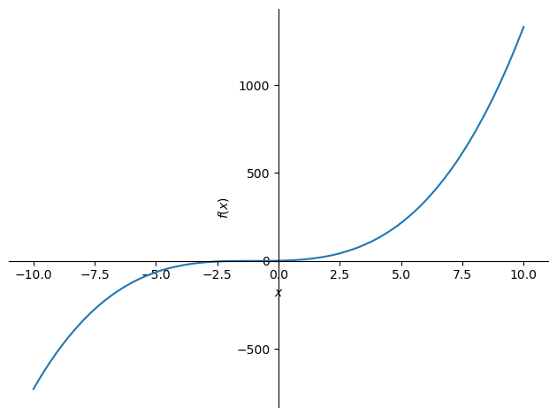

```
<sympy.plotting.plot.Plot at 0x2a1c9a0eb30>
```

```python
sy.plot(trd,show=True)
```

Isso fará com que todos os outros exemplos sejam impressos com caracteres Unicode.

```python
sy.init_printing(use_unicode=True)
```

Para derivadas, utilizamos `diff` e a variável em relação à qual desejamos derivar.

```python
sy.diff(trd,x)
```

$\displaystyle 3 x^{2} + 6 x + 3$

Para integrar, utilizamos `integrate(expressão, variável)` indicando a variável em relação à qual estamos integrando.

```python
sy.integrate(trd,x)
```

$\displaystyle \frac{x^{4}}{4} + x^{3} + \frac{3 x^{2}}{2} + x$

Observação: Quando integrado, ele não apresenta a constante, como em uma integral indefinida. Não sei explicar exatamente o motivo, lamento. :(

```python
sy.integrate(trd,(x,0,2))
```

$\displaystyle 20$

```python
trig = sy.sin(x)
```

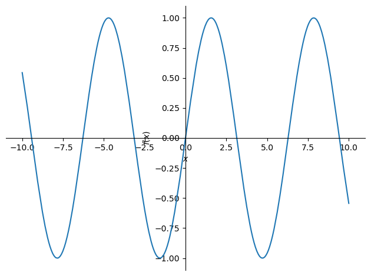

```
<sympy.plotting.plot.Plot at 0x2a1c9d27790>
```

```python
sy.plot(trig)
```

```python
sy.integrate(sy.sin(x**2), (x, -sy.oo, sy.oo))
```

$\displaystyle \frac{\sqrt{2} \sqrt{\pi}}{2}$

Para encontrar o limite, utilizamos `.limit(expressão, variável, para onde vai)`.

```python
sy.limit(trd,x,sy.oo)
```

$\displaystyle \infty$

Você também pode resolver uma equação e descobrir as raízes de uma função utilizando as ferramentas adequadas do SymPy.

```python
sy.solve(trd)
```

$\displaystyle \left[ -1\right]$

o SymPy também suporta resolução de Equações Diferenciais Ordinárias (EDOs)

```python
t = sy.symbols('t')
y = sy.Function('y')
```

```python
y
```

```
y
```

```python
sy.Eq(y(t).diff(t, t) - y(t), sy.exp(t))
```

$\displaystyle - y{\left(t \right)} + \frac{d^{2}}{d t^{2}} y{\left(t \right)} = e^{t}$

```python
sy.dsolve(sy.Eq(y(t).diff(t, t) - y(t), sy.exp(t)), y(t))
```

$\displaystyle y{\left(t \right)} = C_{2} e^{- t} + \left(C_{1} + \frac{t}{2}\right) e^{t}$

Converter uma função para o formato LaTeX para utilizar em textos.

```python
sy.latex(trd)
```

```
'x^{3} + 3 x^{2} + 3 x + 1'
```

Encontrar o autovalor de uma matriz.

```python
sy.Matrix([[1, 2], [2, 2]]).eigenvals()
```

$\displaystyle \left\{ \frac{3}{2} - \frac{\sqrt{17}}{2} : 1, \ \frac{3}{2} + \frac{\sqrt{17}}{2} : 1\right\}$

Reescreva a função de Bessel em termos da função esférica de Bessel.

```python
nu, z = sy.symbols('nu z')
sy.besselj(nu, z).rewrite(sy.jn)
```

$\displaystyle \frac{\sqrt{2} \sqrt{z} j_{\nu - \frac{1}{2}}\left(z\right)}{\sqrt{\pi}}$

### Dominios

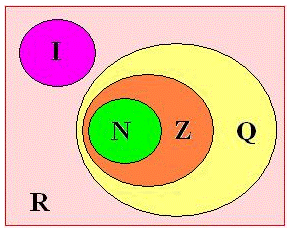

Quando assumimos variáveis simbólicas, é importante especificar os domínios, pois existem propriedades a serem respeitadas em identidades. Isso é crucial para evitar problemas no programa, conforme será explicado mais adiante.

```python
x = sy.symbols('x',domain='QQ')
```

```python
y = sy.symbols('y',domain='ZZ')
```

```python
z = sy.symbols('z',domain='CC_I',positive = True)
```

```python
i = sy.symbols('i',domain='I')
```

```python
x,y,z,i
```

$\displaystyle \left( x, \ y, \ z, \ i\right)$

### EXERCÌCIOS DE INTRODUÇÃO

1.Crie um número simbólico que seja representado apenas dentro dos irracionais, incluindo PI, Euler, phi e i.

```python
#Resolução
```

```python
pi = sy.pi
pi
```

$\displaystyle \pi$

```python
e = sy.E
e
```

$\displaystyle e$

```python
phi = sy.symbols('\phi')
phi
```

$\displaystyle \phi$

```python
i = sy.I
i
```

$\displaystyle i$

1. Faça a formula de Bhaskara usando .roots()

```python
a, b, c = sy.symbols('a b c', real=True)
x = sy.symbols('x', positive=True)
baskara = sy.roots(a*x**2+b*x+c,x)
baskara
```

$\displaystyle \left\{ - \frac{b}{2 a} - \frac{\sqrt{- 4 a c + b^{2}}}{2 a} : 1, \ - \frac{b}{2 a} + \frac{\sqrt{- 4 a c + b^{2}}}{2 a} : 1\right\}$

1. Exprese o nú{mero Pi em 100 digitos:

```python
sy.pi.n(100)
```

$\displaystyle 3.141592653589793238462643383279502884197169399375105820974944592307816406286208998628034825342117068$

1. Faça uma função que checa se a expressão pode ser fatorada.

```python
chek_fat = lambda exp,x=sy.symbols('x'): not(sy.factor(exp)==exp)
```

```python
chek_fat(x**2+x)
```

```
True
```

```python
chek_fat(x**2+1)
```

```
False
```

1. Escreva a seguinte expressão em LaTeX:

$\frac{1}{\sqrt{2\Phi}}e^{\frac{x^{2} + 2}{y - 1}}$

```python
phi = sy.symbols('\phi')
x,y = sy.symbols('x y')
```

```python
exp1 = (1/sy.sqrt(phi*2,evaluate=False))
exp2 = sy.exp((x**2+2)/(y-1))
exp1,exp2
```

$\displaystyle \left( \frac{\sqrt{2}}{2 \sqrt{\phi}}, \ e^{\frac{x^{2} + 2}{y - 1}}\right)$

```python
sy.latex(exp1*exp2)
```

```
'\\frac{\\sqrt{2} e^{\\frac{x^{2} + 2}{y - 1}}}{2 \\sqrt{\\phi}}'
```

### Conteúdos a serem abordados

Não vou aprofundar em todos os tópicos, mas pretendo dividir em quatro partes:

- Introdução (que acabou de acontecer)
- Aprofundamento em funções e variação para as trigonométricas.
- Operações Polinomiais/Impressões
- Plot gráfico (opcional)

A biblioteca pode ir muito além de tudo isso, mas esta é apenas uma introdução. Minha ideia é apresentar mais conceitos de cálculo diferencial e integral, muito utilizados em Engenharias em geral.

# Operações

### Definição simbolicas

Como em polinômios comuns, podemos alterar seus valores. Por exemplo, ao substituir $(x = 0)$ na equação $(x^2 + 1)$, o valor resultante seria 1.

```python
x = sy.symbols('x')
```

```python
y = x**2+2*x+1
```

```python
y.subs(x,0)
```

$\displaystyle 1$

Como em polinômios comuns, podemos alterar seus valores.

```python
z = sy.symbols('z')
```

```python
sy.factor( y.subs(x,z))
```

$\displaystyle \left(z + 1\right)^{2}$

Assim como em polinômios comuns, podemos substituir variáveis por expressões inteiras.

```python
y.subs(x,z-2).expand()
```

$\displaystyle z^{2} - 2 z + 1$

Este conceito também é válido para expressões trigonométricas.

```python
trig = sy.sin(2*x) + sy.cos(2*x)
```

```python
sy.expand_trig(trig)
```

$\displaystyle 2 \sin{\left(x \right)} \cos{\left(x \right)} + 2 \cos^{2}{\left(x \right)} - 1$

Caso tenha mais de uma variável, podemos usar uma lista no formato ([variavel, valor], ... ).

```python
exp = x**3+z**2+1
```

```python
exp.subs([(x,2),[z,2]])
```

$\displaystyle 13$

```python
y = sy.symbols('y')
expr = x**4 - 4*x**3 + 4*x**2 - 2*x + 3
replacements = [(x**i, y**i) for i in range(5) if i % 2 == 0]
expr.subs(replacements)
```

$\displaystyle - 4 x^{3} - 2 x + y^{4} + 4 y^{2} + 3$

```python
strt = 'x**3 + 3'
exp = sy.sympify(strt)
```

```python
exp
```

$\displaystyle x^{3} + 3$

### funções de printar

```python
sy.init_printing()
```

```python
sy.init_session()
```

```
IPython console for SymPy 1.11.1 (Python 3.10.9-64-bit) (ground types: python)

These commands were executed:
>>> from sympy import *
>>> x, y, z, t = symbols('x y z t')
>>> k, m, n = symbols('k m n', integer=True)
>>> f, g, h = symbols('f g h', cls=Function)
>>> init_printing()

Documentation can be found at https://docs.sympy.org/1.11.1/
```

```python
sy.Integral(x**2,x)
```

$\displaystyle \int x^{2}\, dx$

```python
print(sy.Integral(x**2,x))
```

```
Integral(x**2, x)
```

```python
sy.pprint(sy.Integral(x**2,x))
```

```
⌠
⎮  2
⎮ x  dx
⌡
```

```python
sy.pprint(sy.Integral(x**2,x), use_unicode=False)
```

```
  /
 |  2
 | x  dx
/
```

```python
sy.pprint(sy.Integral(x**2,x), use_unicode=True)
```

```
⌠
⎮  2
⎮ x  dx
⌡
```

### Manipulações Polinomiais Básicas.

```python
x, y, z = sy.symbols('x y z')
sy.init_printing(pretty_print=True,scale=1.0, order='grlex',
                    forecolor='Black', backcolor='White',use_unicode =True)
```

- Simplify

Simplifica polinômios básicos (não trigonométricos).

```python
sy.simplify(sy.cos(x)**2+sy.sin(x)**2)
```

$\displaystyle 1$

```python
sy.sympify((x**2+2*x+1)/(x+1))
```

$\displaystyle \frac{x^{2} + 2 x + 1}{x + 1}$

Como o SymPy tem uma visão não simplificada de $x^2 + 2x + 1$, ele simplesmente não realiza a fatoração automaticamente. Na mente humana, normalmente realizamos a fatoração do primeiro termo e, em seguida, a simplificação.

```python
sy.sympify(sy.factor(x**2+2*x+1)/(x+1))
```

$\displaystyle x + 1$

```python
sy.simplify(x**2 + 2*x + 1)
```

$\displaystyle x^{2} + 2 x + 1$

Com isso, podemos concluir que a função `simplify` do SymPy não realiza a fatoração de um polinômio.

Além da função `simplify`, para trabalhar com funções, temos outras opções:

- `expand`
- `factor`
- `collect`
- `cancel`
- `apart`

Caso tenhamos uma função simplificada, matematicamente, é aconselhável verificar e, se necessário, expandi-la.

```python
x**2 + 2*x+ 1 == (x+1)**2
```

```
False
```

Sabemos que matematicamente ela é verdadeira, e o `expand` mostra isso para nós.

1. Expand

A função `expand` é utilizada para expandir expressões matemáticas, tornando-as mais detalhadas e revelando termos adicionais que podem estar ocultos.

```python
sy.expand((x+1)**2)
```

$\displaystyle x^{2} + 2 x + 1$

```python
sy.expand((x+1)**2) == x**2 + 2*x + 1
```

```
True
```

1. Factor

A função `factor` realiza o oposto da expansão. Ela é utilizada para fatorar expressões, simplificando-as e representando-as como produtos de fatores.

```python
sy.factor(x**2+2*x+1)
```

$\displaystyle \left(x + 1\right)^{2}$

```python
sy.factor(x**2+2*x+1) == (x+1)**2
```

```
True
```

1. Collect

A função `collect` é utilizada para colocar uma variável simbólica em evidência, agrupando termos semelhantes e organizando a expressão de acordo com a potência dessa variável.

```python
sy.collect(x*y + x - 3 + 2*x**2 - z*x**2 + x**3,x)
```

$\displaystyle x^{3} + x^{2} \cdot \left(- z + 2\right) + x \left(y + 1\right) - 3$

O método `coeff` da função `collect` permite extrair o valor associado a um determinado termo, multiplicando-o pelo(s) coeficiente(s) do(s) expoente(s) específico(s).

```python
sy.collect(x*y + x - 3 + 2*x**2 - z*x**2 + x**3,x).coeff(x, 2)
```

$\displaystyle - z + 2$

```python
sy.collect(x**3 + x**2*(y+1)+x**2*(10),x).coeff(x, 2)
```

$\displaystyle y + 11$

1. Cancel

A função `cancel` é conhecida como o nosso famoso "corta-corta", onde variáveis semelhantes podem ser canceladas em expressões matemáticas.

```python
sy.cancel((x**2+x)/x)
```

$\displaystyle x + 1$

Na função `cancel`, ela utiliza o método `.factor`, que por sua vez realiza a fatoração dos polinômios para simplificá-los ainda mais.

```python
sy.cancel((x**2+2*x+1)/(x+1))
```

$\displaystyle x + 1$

1. Apart

A função `apart` é utilizada quando temos uma expressão $\frac{f(x)}{g(x)}$, onde podemos cancelar partes de $f(x)$ por $g(x)$. Em resumo, para quem já estudou Cálculo II na UFGD e Cálculo III na UEMS e se lembra de integrais por frações parciais, o `apart` realiza essa construção da nova função para a integração parcial.

```python
f1 = x**3+16
f2 = x**3-4*x**2+8*x
f1/f2
```

$\displaystyle \frac{x^{3} + 16}{x^{3} - 4 x^{2} + 8 x}$

```python
sy.apart(f1/f2)
```

$\displaystyle \frac{2 x}{x^{2} - 4 x + 8} + 1 + \frac{2}{x}$

Ocorre algo muito comum na expressão acima; deveria poder resultar em um número irracional, no entanto, isso não ocorreu. Contudo, não há um erro em si.

```python
sy.apart(f1/f2, domain='QQ_I')
```

$\displaystyle 1 + \frac{1 + i}{x - 2 + 2 i} + \frac{1 - i}{x - 2 - 2 i} + \frac{2}{x}$

Por isso temos que saber definir dominios se não a resolução vem aparentemente errada porem não ta errada.

### Simplificações trigonométricas.

```python
sy.trigsimp(sy.sin(x)**2+sy.cos(x)**2)
```

$\displaystyle 1$

```python
sy.trigsimp(2*sy.sin(x)*sy.cos(x))
```

$\displaystyle \sin{\left(2 x \right)}$

Em geral, todas as propriedades trigonométricas são utilizáveis para isso.

Seu oposto é a `expand_trig`.

```python
sy.expand_trig(abs(sy.cos(x-y)))
```

$\displaystyle \left|{\sin{\left(x \right)} \sin{\left(y \right)} + \cos{\left(x \right)} \cos{\left(y \right)}}\right|$

Observação: Tentei expandir vários valores das tabelas trigonométricas, mas a maioria não foi possível. No entanto, os valores tradicionais foram bem-sucedidos.

# Exercícios Trigonometria

Prove as seguintes razões:

- $sen²x + cos²x = 1$
- $1- cos2x = 2sen²x$
- $2sinxcosx = sen2x $

```python
#Resolução
x = sy.symbols('x')
```

```python
sy.trigsimp(sy.sin(x)**2+sy.cos(x)**2) == 1
```

```
True
```

```python
sy.trigsimp(1-sy.cos(2*x)) == 2*sy.sin(x)**2
```

```
True
```

```python
sy.trigsimp(2*sy.sin(x)*sy.cos(x))== sy.sin(2*x)
```

```
True
```

### Exponenciais

regras basicas:

1. $x^a*x^b == x^{a+b}$
2. $x^{m^n} == x^{n*m}$
3. ${(a*b)}^{x} == a^xb^x$

Primeiro, vou explorar notações reais que podem não ser consideradas reais no SymPy.

```python
x, y = sy.symbols('x y', positive=True)
a, b = sy.symbols('a b', real=True)
```

```python
x**a*x**b == x**(a+b)
```

```
False
```

```python
x**a*y**a == (x*y)**a
```

```
False
```

```python
(x**a)**b == x**(a*b)
```

```
True
```

Outra forma de representar raízes é o racional, sabendo que a raiz de $\sqrt{x^a}$ é $\sqrt[\leftroot{-2}\uproot{2}a]{x}$."

```python
x**sy.Rational(1,2)
```

$\displaystyle \sqrt{x}$

```python
sy.sqrt(x) == x**sy.Rational(1,2)
```

```
True
```

```python
sy.powsimp(x**a*x**b)
```

$\displaystyle x^{a + b}$

```python
sy.powsimp((x**a)*(y**a))
```

$\displaystyle \left(x y\right)^{a}$

Problemas podem surgir ao gerar símbolos quando suas propriedades não são definidas. Nesses casos, forçamos o programa a produzir a saída desejada.

```python
f,g,h = sy.symbols('f g h')
```

```python
sy.powsimp((f**h)*(g**h))
```

$\displaystyle f^{h} g^{h}$

```python
sy.powsimp((f**h)*(g**h), force=True)
```

$\displaystyle \left(f g\right)^{h}$

Também podemos gerar as saídas inversas das que geramos anteriormente usando a função `expand_power_base`.

```python
sy.expand_power_base((x*y)**a)
```

$\displaystyle x^{a} y^{a}$

A notação `force=True` ainda é válida nesse caso.

```python
sy.powdenest((x**a)**b)
```

$\displaystyle x^{a b}$

O `force=True` também é válido para esses casos, onde não definimos os domínios dos símbolos, se são inteiros, reais ou apenas positivos. Tudo isso é determinante.

### Logaritmos e exponenciais

Identidades Gerais:

1. $\log{(xy)} = \log{(x)} + \log{(y)}$
2. $\log{(x^n)} = n\log{(x)}$
3. $\log{\left(\frac{x}{y}\right)} = \log(x) - \log(y)$

Ao utilizar logaritmos, farei uma organização nas minhas variáveis simbólicas em relação ao domínio

```python
x,y = sy.symbols('x y', positive=True)
n,k = sy.symbols('n k', real=True)
```

Para ter uma compreensão básica, geralmente o logaritmo na base 10 é representado como $\log(x)$, e é diferente do logaritmo natural, denotado por $\ln(x)$.

```python
sy.log(x) == sy.ln(x)
```

```
True
```

No SymPy, concluímos que todo logaritmo é na base natural de Euler.

- `expand_log()`

Como demonstrado nos exemplos anteriores, esta função é utilizada para expandir funções logarítmicas e segue as identidades associadas.

```python
sy.expand_log(sy.log(x*y))
```

$\displaystyle \log{\left(x \right)} + \log{\left(y \right)}$

```python
sy.expand_log(sy.log(x/y))
```

$\displaystyle \log{\left(x \right)} - \log{\left(y \right)}$

```python
sy.expand_log(sy.log(x**n))
```

$\displaystyle n \log{\left(x \right)}$

- `logcombine()`

Esta função é similar a um `.factor` para logaritmos.

```python
sy.logcombine(sy.log(x)+sy.log(y))
```

$\displaystyle \log{\left(x y \right)}$

```python
sy.logcombine(sy.log(x)-sy.log(y))
```

$\displaystyle \log{\left(\frac{x}{y} \right)}$

```python
sy.logcombine(n*sy.log(x))
```

$\displaystyle \log{\left(x^{n} \right)}$

Lembrando que existem domínios, e não considerar domínios ao assumir números simbólicos pode levar a resultados inesperados, sendo necessário, em alguns casos, forçar a ocorrência desejada.

### Especiais símbolos

- Fatorial

O fatorial de $n$, denotado por $n!$, é o produto de todos os números inteiros positivos de 1 até $n$. Matematicamente, é definido como:

$n! = n \times (n-1) \times (n-2) \times \ldots \times 3 \times 2 \times 1 \$

No SymPy, você pode usar a função `factorial` para calcular o fatorial de um número.

```python
sy.factorial(n)
```

$\displaystyle n!$

- Binomial

Coeficiente binomial e ao Triângulo de Pascal, que são conceitos associados ao Binômio de Newton.

O coeficiente binomial, denotado como $\binom{n}{k} $ ou $ C(n, k)$, representa o número de maneiras diferentes de escolher $ k $ elementos de um conjunto de $ n $ elementos sem levar em consideração a ordem. É calculado pela fórmula:

$ \binom{n}{k} = \frac{n!}{k!(n-k)!} $

O Triângulo de Pascal é uma representação gráfica dos coeficientes binomiais. Cada número no triângulo é a soma dos dois números diretamente acima dele. Ele é frequentemente usado para expandir binômios elevados a uma potência.

Para usar na SymPy usamos `binomial`.

```python
sy.binomial(n,k)
```

$\displaystyle {\binom{n}{k}}$

- Gamma

A função gama $\Gamma$, também conhecida como função gama de Euler, é uma extensão dos fatoriais para números complexos e números reais não inteiros. A função gama é definida pela integral:

$ \Gamma(z) = \int_0^\infty t^{z-1}e^{-t} \, dt $

Para números inteiros positivos, a função gama está relacionada ao fatorial como $\Gamma(n) = (n-1)!$ para $n \in \mathbb{N}$.

No SymPy, você pode usar a função `gamma` para calcular a função gama.

```python
sy.gamma(n)
```

$\displaystyle \Gamma\left(n\right)$

- hyper

Função hipergeométrica ou a algo relacionado a funções hipergeométricas. A função hipergeométrica é uma função especial que pode ser denotada como $\,_pF_q(a_1, a_2, \ldots, a_p; b_1, b_2, \ldots, b_q; z)$.

A função hipergeométrica generaliza várias funções conhecidas, incluindo funções trigonométricas, exponenciais e logarítmicas. Ela é definida pela série hipergeométrica:

$\,_pF_q(a_1, a_2, \ldots, a_p; b_1, b_2, \ldots, b_q; z) = \sum_{n=0}^{\infty} \frac{(a_1)_n (a_2)_n \ldots (a_p)_n}{(b_1)_n (b_2)_n \ldots (b_q)_n} \frac{z^n}{n!}$

Aqui, $(a)_n$ denota o símbolo de Pochhammer, que é uma generalização do fatorial.

```python
sy.hyper([a1,a2],[a3],n)
```

$\displaystyle {{}_{2}F_{1}\left(\begin{matrix} a_{0}, a_{1} \\ a_{2} \end{matrix}\middle| {n} \right)}$

- meijerg

A função meijerg no SymPy é utilizada para representar funções G de Meijer, que são uma classe de funções integrais generalizadas. Essas funções envolvem integrais definidas e podem representar várias funções especiais.

A forma geral da função G de Meijer no SymPy é meijerg([a₁, ..., aₖ], [b₁, ..., bₗ], [c₁, ..., cₘ], [d₁, ..., dₙ], z)

```python
meijerg((1, 2), (a, 4), (5,), [], x)
```

$\displaystyle {G_{4, 1}^{1, 2}\left(\begin{matrix} 1, 2 & a, 4 \\5 & \end{matrix} \middle| {x} \right)}$

OBS:

```
1. função hipergeométrica tem muitas propriedades e casos especiais, e seu comportamento pode variar dependendo dos parâmetros.
2. A função gama é utilizada em diversas áreas da matemática e da física, e suas propriedades são extensas.
```

- `.rewrite()`

SymPy é usada para reescrever uma expressão em uma forma alternativa. Isso pode ser útil para simplificar ou alterar a aparência de uma expressão sem mudar seu significado.

```python
sy.tan(x).rewrite(sy.cos(x))
```

$\displaystyle \frac{\cos{\left(x - \frac{\pi}{2} \right)}}{\cos{\left(x \right)}}$

```python
sy.factorial(n).rewrite(sy.gamma)
```

$\displaystyle \Gamma\left(n + 1\right)$

expand_func()

funções especiais teremos que usar a expand func

```python
sy.expand_func(sy.gamma(x+4))
```

$\displaystyle x \left(x + 1\right) \left(x + 2\right) \left(x + 3\right) \Gamma\left(x\right)$

- `hyperexpand()`

É utilizada para expandir uma expressão que envolve funções hipergeométricas. A expansão pode envolver a expressão em termos de funções elementares mais simples ou outras funções especiais

Este é um exemplo básico. A função `hyperexpand()` é especialmente útil quando você tem expressões envolvendo funções hipergeométricas e deseja simplificar ou expandir a expressão em termos de funções mais familiares.

```python
sy.hyperexpand(sy.hyper([1, 1], [2], n))
```

$\displaystyle - \frac{\log{\left(- n + 1 \right)}}{n}$

```python
sy.hyperexpand(sy.hyperexpand(sy.hyper([1, 1], [2], n)))
```

$\displaystyle - \frac{\log{\left(- n + 1 \right)}}{n}$

E temos como fazer simplificações nelas

```python
sy.combsimp(sy.factorial(n)/sy.factorial(n - 3))
```

$\displaystyle n \left(n - 2\right) \left(n - 1\right)$

```python
sy.combsimp(sy.binomial(n+1, k+1)/sy.binomial(n, k))
```

$\displaystyle \frac{n + 1}{k + 1}$

porem a gamma tem uma específica gammasimp

```python
sy.gammasimp(sy.gamma(x)*sy.gamma(1 - x))
```

$\displaystyle \frac{\pi}{\sin{\left(\pi x \right)}}$

Assim, concluímos a parte de operações básicas. Vamos resolver tudo agora.

# Cálculos e Solução de Equações

Nessa parte da aula, trataremos de resolver equações. Começaremos com polinômios algébricos e, em seguida, abordaremos limites, derivadas e integrais.

```python
from sympy.plotting import plot
x, y, z = sy.symbols('x:z', domain='ZZ_I')
sy.init_printing(pretty_print=True,scale=1.0, order='grlex',
                    forecolor='Black', backcolor='White',use_unicode =True)
```

```python
f = sy.Eq(x,y)
f
```

$\displaystyle x = y$

```python
#Função so do lado esquerdo
f.lhs
```

$\displaystyle x$

```python
#função só do lado direito
f.rhs
```

$\displaystyle y$

```python
f = sy.Eq(x**2+3,y)
```

```python
f
```

$\displaystyle x^{2} + 3 = y$

```python
#REsolver esquação
f.subs({x:3})
```

$\displaystyle 12 = y$

```python
#REtornou o boleano pois ele checa se houve a vereificação
f.subs({x:3,y:12})
```

$\displaystyle \text{True}$

### Resolver as equações para igualdade

O primeiro comando para resolver envolve pegar uma equação, uma variável simbólica, e determinar os domínios ou valores únicos nos quais a equação é verdadeira.

```python
sy.solveset(sy.Eq(x**2+2*x+1,10),x)
```

$\displaystyle \left\{-1 + \sqrt{10}, - \sqrt{10} - 1\right\}$

```python
sy.solveset((x-1)*(x+2)*(x+7)*x,x)
```

$\displaystyle \left\{-7, -2, 0, 1\right\}$

Há casos em que são resolvidos considerando domínios específicos.

```python
sy.solveset(x - x, x)
```

$\displaystyle \mathbb{C}$

```python
sy.solveset(sy.sin(x),1)
```

$\displaystyle \emptyset$

E casos que não temos uma solução.

```python
sy.solveset(sy.exp(x),x)
```

$\displaystyle \emptyset$

```python
sy.solveset(sy.cos(x)-x,x)
```

$\displaystyle \left\{x\; \middle|\; x \in \mathbb{C} \wedge - x + \cos{\left(x \right)} = 0 \right\}$

### Sistemas

Quando se trata de resolver um sistema usando `linsolve`.

```python
eqs = [x+y+z+2,x+y-4,x-1]
```

```python
sy.linsolve(eqs,(x,y,z))
```

$\displaystyle \left\{\left( 1, \ 3, \ -6\right)\right\}$

```python
sy.linsolve([x + y + z - 1, x + y + 2*z - 3 ], (x, y, z))
```

$\displaystyle \left\{\left( - y - 1, \ y, \ 2\right)\right\}$

tambem funcina em matrizes.

```python
sy.linsolve(sy.Matrix(([1, 1, 1, 1], [1, 1, 2, 3])), (x, y, z))
```

$\displaystyle \left\{\left( - y - 1, \ y, \ 2\right)\right\}$

Existe a função `nonlinsolve` que resolve e fornece soluções tanto para variáveis simbólicas quanto para variáveis não simbólicas. Ao contrário da `linsolve`, não requer um sistema de equações para determinar os valores das variáveis e permite soluções que incluem valores negativos.

```python
a, b, c, d = sy.symbols('a:d', real=True)
```

```python
sy.nonlinsolve([a**2 + a, a - b], [a, b])
```

$\displaystyle \left\{\left( -1, \ -1\right), \left( 0, \ 0\right)\right\}$

```python
sy.nonlinsolve([x*y - 1, x - 2], x, y)
```

$\displaystyle \left\{\left( 2, \ \frac{1}{2}\right)\right\}$

E o conjunto de existência, caso a representação de todos os números ultrapasse os limites dos números existentes.

```python
sy.nonlinsolve([sy.exp(x) - sy.sin(y), 1/y - 3], (x,y))
```

$\displaystyle \left\{\left( \left\{2 n i \pi + \log{\left(\sin{\left(\frac{1}{3} \right)} \right)}\; \middle|\; n \in \mathbb{Z}\right\}, \ \frac{1}{3}\right)\right\}$

tem a representção de numeros complexos.

```python
sy.nonlinsolve([x**2 + 1, y**2 + 1], [x, y])
```

$\displaystyle \left\{\left( - i, \ - i\right), \left( - i, \ i\right), \left( i, \ - i\right), \left( i, \ i\right)\right\}$

Sistema com infinitas soluções tambem são solucionaveis.

```python
sy.nonlinsolve([x*y, x*y - x], [x, y])
```

$\displaystyle \left\{\left( 0, \ y\right)\right\}$

Caso tenha uma letra para a qual não seja necessária uma representação específica, podemos simplesmente usá-la.

```python
sy.nonlinsolve([a**2 + a*c, a - b], [a, b])
```

$\displaystyle \left\{\left( 0, \ 0\right), \left( - c, \ - c\right)\right\}$

Para extrair as raízes de um polinômio, temos a função `roots`.

```python
sy.roots(x**2+2*x+1)
```

$\displaystyle \left\{ -1 : 2\right\}$

### Limite

Como sabemos os limites se dão pela seguinte formula $\lim_{x\to x_0} f(x)$

Para mexer com algo mais visual temos que

```python
sy.Limit(sy.sin(x),x,sy.oo)
```

$\displaystyle \lim_{x \to \infty} \sin{\left(x \right)}$

e para resolver é so da doit

```python
sy.Limit(sy.sin(x),x,sy.oo).doit()
```

$\displaystyle \left\langle -1, 1\right\rangle$

```python
sy.limit(sy.sin(x),x,sy.oo)
```

$\displaystyle \left\langle -1, 1\right\rangle$

Sabemos também que ela pode tender para o limite infinito positivo e infinito negativo, e isso varia de acordo com como ela pode se comportar. Temos uma parte do código que lida com para onde podemos fazer esse infinito.

```python
sy.limit(1/x,x,0,'+')
```

$\displaystyle \infty$

```python
sy.limit(1/x,x,0,'-')
```

$\displaystyle -\infty$

Para as identidades, nunca se esqueça que é muito mais valioso para uma derivada sua construção do que sua armação. No início, ao manipular polinômios, a parte de arrumá-los contribui muito mais para o limite do que para outros, seja para trigonometria ou limites, no que se trata de programação.

# Exercícios de Limite

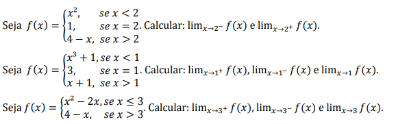

```python
from sympy import *
#import sympy as sy
sy.init_printing()
```

```python
x = symbols('x')
```

```python
fcs = [x**2,1,4-x]
```

```python
limit(fcs[0],x,2,'-')
```

$\displaystyle 4$

```python
limit(fcs[2],x,2,'+')
```

$\displaystyle 2$

```python
#Execício 2
fcs = [x**3+1,3,x+1]
limit(fcs[0],x,1,'-'),limit(fcs[1],x,1),limit(fcs[2],x,1,'-')
```

$\displaystyle \left( 2, \ 3, \ 2\right)$

```python
#Exercício 3
fcs = [x**2-2*x,4-x]
limit(fcs[0],x,1,'-'),limit(fcs[0],x,1),limit(fcs[1],x,1,'-')
```

$\displaystyle \left( -1, \ -1, \ 3\right)$

### Derivada

Derivadas podem se feitas tanto como aplicando o limite por definição como tambem por derivada base $\lim_{h\to 0} \frac{f(x+h)-f(x)}{h}$

```python
h = sy.symbols('h')
```

```python
exp= x**2
```

```python
sy.limit(sy.cancel((sy.expand(exp.subs(x,x+h))-exp)/h),h,0)
```

$\displaystyle 2 x$

so que como todo bom programador vamos de inteligencia e eficiaencia com a `.diff`

```python
exp.diff()
```

$\displaystyle 2 x$

```python
exp.diff(x,2)
```

$\displaystyle 2$

Podemos usar o `Derivative` tbem para fazer isso. Tem a mesma funçao do `diff()`.

Como no `Limit/limit`, onde um cria uma instância de limite e temos visualização, e no outro criamos o resultado do limite.

`Derivate` e `diff` têm a mesma ideia: um cria a instância com o `__str__` printando a derivada, o outro cria apenas o resultado.

```python
exp = x**2*y**4*z
```

```python
deriv = sy.Derivative(exp,x,2,y,4,z)
```

Como mostrado anteriomente se derivado da forma conde temos a (exp,var1,N vezes, var2, nvezes, ...) serve tanto para diff quanto para derivate

```python
deriv
```

$\displaystyle \frac{\partial^{7}}{\partial z\partial y^{4}\partial x^{2}} x^{2} y^{4} z$

```python
deriv.doit()
```

$\displaystyle 48$

# Exercícios de Derivadas

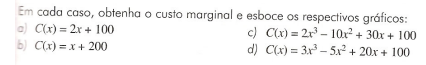

```python
def custo_marginal(exp,x=symbols('x')):
    print('Derivada:',exp.diff())
    plot((exp,(x,-10,10)),(exp.diff(),(x,-10,10)),legend=True)
```

```python
custo_marginal(3*x**3+5*x**2+20*x+100)
```

```
Derivada: 9*x**2 + 10*x + 20
```

```python
custo_marginal(2*(x**3)-10*x**2+30*x+100)
```

```
Derivada: 6*x**2 - 20*x + 30
```

OBS: custo marginal é a 1ª derivada e o grafico com a sy.plot()caso de para fazer

```python
custo_marginal(2*x + 100)
```

```
Derivada: 2
```

```python
custo_marginal(x+200)
```

```
Derivada: 1
```

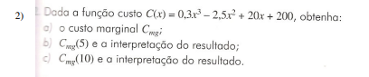

```python
#Resolução
c = 0.3*x**3-2.5*x**2+20*x+200
```

```python
c.diff()
```

$\displaystyle 0.9 x^{2} - 5.0 x + 20$

```python
c.diff().subs(x,5)
```

$\displaystyle 17.5$

```python
c.diff().subs(x,10)
```

$\displaystyle 60.0$

```python
aux = (x,0,50)
plot((c,aux),(c.diff(),aux),legend=True)
```

```
<sympy.plotting.plot.Plot at 0x2a1cede8f10>
```

Complemento da atividade de hoje: https://drive.google.com/file/d/1ReaNsTvugSB8ruwTP7eBxhlE3n-FE01X/view?usp=drive_link

### Intregrais

Como toda integral, existem dois tipos de integrais: definidas e indefinidas, que são resolvidas das seguintes formas:

As indefinidas se da por sem limite

$\int\ f(x)\,dx$

```python
sy.integrate(x**3, x)
```

$\displaystyle \frac{x^{4}}{4}$

Como toda integral indefinada( ou anti-derivada ou primitiva como você aparedeu quando entrou nesse mundo do calculo diferencial integral) vemos que não tem constante, cada constete SUMIU? nun sei dize.

Para as definada temos

$\int_a^b f(c)\,dx$

```python
sy.integrate(x**3, (x,0,2))
```

$\displaystyle 4$

Como sabemos tbem tem como resolver integrais duplas triplas e assim por diante

$\int_{a}^{b}\int_{c}^{d} F(x,y)\, dx\, dy$

```python
sy.integrate(x**3 + y**3, (x,0,2),(y,0,2))
```

$\displaystyle 16$

E assim como como derivada e limite tem uma função para armazenar a integral

```python
exrp = sy.Integral(sy.cos(x)*sy.sin(x),x)
```

```python
exrp
```

$\displaystyle \int \sin{\left(x \right)} \cos{\left(x \right)}\, dx$

```python
exrp.doit()
```

$\displaystyle \frac{\sin^{2}{\left(x \right)}}{2}$

```python
integ = sy.Integral(x**y*sy.exp(-x), (x,0, sy.oo))
```

```python
integ
```

$\displaystyle \int\limits_{0}^{\infty} x^{y} e^{- x}\, dx$

```python
integ.doit()
```

$\displaystyle \begin{cases} \Gamma\left(y + 1\right) & \text{for}\: \operatorname{re}{\left(y\right)} > -1 \\\int\limits_{0}^{\infty} x^{y} e^{- x}\, dx & \text{otherwise} \end{cases}$

Esse é um codigo da própria documentação para mostrar qunado o limite tem diferentes tratamentos de acodo de onde ele se encotra

# EXERCÍCIOS DE INTEGRAIS

Resolva as seguintes integrais:

1. $\int\limits_{1}^{e}\int\limits_{0}^{x} \frac{1}{x^{2} + y^{2}}\, dx\, dy$
2. $\int\int\limits_{R}dxdy$, R{ 2<x<4 , 1<y<10 }
3. $\int\limits_{0}^{1}\int\limits_{0}^{2} x+2\,dx\, dy$
4. D = {(x, y, z) / 0 ≤ x ≤ 3, 0 ≤ y ≤ 2, 0 ≤ z ≤ 1}, f(x,y,x) = $x^2+ y^2 + z^2$

```python
#Resolução
```

Aplicações da aula: https://drive.google.com/file/d/1vfe4akhzqQ8uMvcij_tKVnyEJQtMy4Bz/view?usp=sharing

### Series

```python
f= sy.symbols('f', cls=Function)
```

```python
x0 = sy.symbols('x_o')
```

$f(x)+ f(x)'(x - x_{0}) + \frac{f(x)''}{2!}(x - x_{0})^{2} + \frac{f(x)''' }{3!}(x - x_{0})^{3} + ...$

o exercíco se basea na serie de tylor, que pode virar a serie de maclaurin caso $x_0$ seja = 0

```python
expr = sy.exp(x)
```

```python
expr
```

$\displaystyle e^{x}$

```python
expr.series(x,x0,5)
```

$\displaystyle e^{x_{o}} + \left(x - x_{o}\right) e^{x_{o}} + \frac{\left(x - x_{o}\right)^{2} e^{x_{o}}}{2} + \frac{\left(x - x_{o}\right)^{3} e^{x_{o}}}{6} + \frac{\left(x - x_{o}\right)^{4} e^{x_{o}}}{24} + O\left(\left(x - x_{o}\right)^{5}; x\rightarrow x_{o}\right)$

```python
expr.series(x,0,5)
```

$\displaystyle 1 + x + \frac{x^{2}}{2} + \frac{x^{3}}{6} + \frac{x^{4}}{24} + O\left(x^{5}\right)$

Esse big O no final apenas para respresentar a ordem não nescessariamente é igual de algortmos de programação a notação Big O

tem uma função que a remove

```python
expr.series(x,0,5).removeO()
```

$\displaystyle \frac{x^{4}}{24} + \frac{x^{3}}{6} + \frac{x^{2}}{2} + x + 1$

# Exercícios de Série

Resolvas as seguintes exercícios:

1. Mostre que {xn = cos(πn)} nao tem limite
2. Mostre que $\lim_{n→∞} \sqrt(n!) = ∞$
3. Determine os quatro primeiros termos de cada seqüência, analise a sua convergência e encontre o limite caso exista:

   a)$a_{n} = \frac{n^2}{n+2}$

   b)$y_{n} = \frac{(-1)^n}{(2n)!}$

```python
#resolve
```

### Diferenciações Finitas

```python
f, g = sy.symbols('f g', cls=sy.Function)
```

```python
sy.differentiate_finite(f(x)*g(x))
```

$\displaystyle - f{\left(x - \frac{1}{2} \right)} g{\left(x - \frac{1}{2} \right)} + f{\left(x + \frac{1}{2} \right)} g{\left(x + \frac{1}{2} \right)}$

Com uma derivate podemos instanciar a differentiate_finite

```python
f = sy.Function('f')
```

```python
dfdx = f(x).diff(x)
```

```python
dfdx.as_finite_difference()
```

$\displaystyle - f{\left(x - \frac{1}{2} \right)} + f{\left(x + \frac{1}{2} \right)}$

### Equações Diferenciais

defunir um simbolos não se baseia somente em definir como x ou y existes os simbolos f(x) e g(x) ou na fisica quando V(x) para definir uma eq para.

```python
f, g = sy.symbols('f g', cls=sy.Function)
```

```python
f(x)
```

$\displaystyle f{\left(x \right)}$

A diff funcina para resolver a parte de dervar voce pode deixar com parametro da variavel que ele vai derivada e por quantas vezes for esse parametro para ele derivar

```python
f(x).diff()
```

$\displaystyle \frac{d}{d x} f{\left(x \right)}$

```python
f(x).diff(x, x)
```

$\displaystyle \frac{d^{2}}{d x^{2}} f{\left(x \right)}$

para criar a equação diferencial usamos o eq(syst,solut)

```python
differencer = sy.Eq(f(x).diff(x, x) + f(x).diff() + f(x),0)
```

```python
differencer
```

$\displaystyle f{\left(x \right)} + \frac{d}{d x} f{\left(x \right)} + \frac{d^{2}}{d x^{2}} f{\left(x \right)} = 0$

```python
sy.dsolve(differencer,f(x))
```

$\displaystyle f{\left(x \right)} = \left(C_{1} \sin{\left(\frac{\sqrt{3} x}{2} \right)} + C_{2} \cos{\left(\frac{\sqrt{3} x}{2} \right)}\right) e^{- \frac{x}{2}}$

Em calculo 2 aprendemos varias coisas das esquações diferenciais de segunda ondem onde uma caem nos 3 casos genericos

# PROBLEMAS DE OTIMIZAÇÃO

Dentre as muitas formar de usar da matematica os problemas de otimização usadno primeira e segunda derivada é muito comum e utilizados abaixo usaremos uma função aleatoria e tiraremos o seu gráfico no final.

```python
x = sy.symbols('x')
y = sy.Function('y')
f = x**3 - 2*x**2 + 2
```

```python
# A primeira derivada
f_diff = sy.diff(f,x,1)
f_diff
```

$\displaystyle 3 x^{2} - 4 x$

```python
#Segunda derivada
s_diff = sy.diff(f, x, 2)
s_diff
```

$\displaystyle 2 \cdot \left(3 x - 2\right)$

Encontraremos os pontos críticos da primeira derivada

```python
p_critc = sy.solve(f_diff,x)
p_critc
```

$\displaystyle \left[ 0, \ \frac{4}{3}\right]$

E com a segunda derivada vemos se ele é Maximo ou minimo local ou real

- Caso f"(x) > 0 minimo
- Caso f"(x) < 0 Maximo

```python
s_diff.subs({x:p_critc[0]}),s_diff.subs({x:p_critc[1]})
```

$\displaystyle \left( -4, \ 4\right)$

```python
pont_inflexao = sy.solve(s_diff,x)
pont_inflexao
```

$\displaystyle \left[ \frac{2}{3}\right]$

```python
sy.plot((f,(x,p_critc[0]-0.5,p_critc[1]+0.5)),(f.subs(x,p_critc[0]),(x,p_critc[0]-0.1,p_critc[0]+0.1)),(f.subs(x,p_critc[1]),(x,p_critc[1]-0.1,p_critc[1]+0.1)),(f.subs(x,pont_inflexao[0]),(x,pont_inflexao[0]-0.1,pont_inflexao[0]+0.1)))
```

[output not shown]

```
<sympy.plotting.plot.Plot at 0x2a1ca1ebf70>
```

# EXERCÍCIO

a minimização do custo de construção de um tanque

Em nosso exemplo, consideraremos um tanque cilíndrico de volume fixo (V) e desejamos determinar o comprimento (L) e o diâmetro (D) que minimizam o custo do tanque. O custo por unidade de área da lateral do tanque é $C_s$ e o custo por unidade de área do topo e do fundo do tanque é $C_t$. Com um pouco de geometria básica apresentada na figura a seguir, conseguir obter nossa função $f$ que representa o custo:

[figure not shown]

resoluçao: https://cienciaprogramada.com.br/2022/04/problemas-de-otimizacao-python/

```python
#Resolvce
```

# EXTRA PLOTAGEM

É possível fazer plots também com a própria SymPy.

OBS: No Google Colab, sempre há uma grande margem de erro.

A SymPy usa a função `plot` para realizar diferentes plotagens, seguindo N tipos de parâmetros que podem ser passados. Dentre os parâmetros iniciais importantes estão:

- `args`: que é a função simbólica a ser plotada.
- `show`: TRUE ou FALSE (caso queira adicionar mais um gráfico).

```python
x = sy.symbols('x')
```

```python
p1 = sy.plot(x**3,show=False)
p2 = sy.plot(3*x,x*x,show=False)
```

```python
p1
```

```
<sympy.plotting.plot.Plot at 0x2a1cd450af0>
```

```python
p1.show()
```

Adicinar elementos na sua plotagens com outros gráficos metodo .append()

```python
p1.append(p2[0])
```

```python
p1.show()
```

```python
p1.extend(p2)
```

```python
p1.show()
```

Delimitar um espaço condicional normalnete já é pré setado de -10,10

obs: a funcão pode ser mais de uma tbem não nescessariamente apenas uma

```python
sy.plot(x**3,x,x**2,(x,2,-2))
```

```
<sympy.plotting.plot.Plot at 0x2a1cf53b0a0>
```

Pode se dar diferentes ranges para elas

```python
sy.plot((x**3,(x,2,-2)),(x,(x,10,-10)),(x**2,(x,5,-5)))
```

```
<sympy.plotting.plot.Plot at 0x2a1cf53ace0>
```

# PROJETO FINAL

Fazer uma calculadora de custo minimo de função onde você entra com uma função e ela da:

- Maximo ou/e minimo local ou real.
- Reta tangente(caso tenha)
- Raizes(caso tenha)
- Seu custo minimo e uma plotagem em uma area aceitavel que fique visualmente bom.
- Usa a tkinter ou uma biblioteca de sua preferencia para isso

```python
from tkinter import *
from sympy import *
from PIL import Image, ImageTk
sy.init_printing()
```

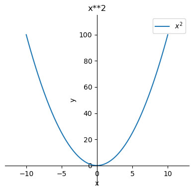

```
<sympy.plotting.plot.Plot at 0x21266dbe260>
```

```python
sy.plot('x**2',title='x**2', xlabel='x', ylabel='y', aspect_ratio='auto',
         axis_center='auto', axis=True,legend=True, autoscale=True,
        margin=0.15, backend='default', size=(4,4),)
```

```python
class App():

    def __init__(self):
        self.janela_p = Tk()
        self.janela_p.title('Custo mínimo de gráfico')
        self.janela_p.geometry('400x500')
        self.janela_p.protocol("WM_DELETE_WINDOW")
        self.janela_p.resizable(False, False)
        self.entrace = Frame(self.janela_p)
        self.janela_g = Frame(self.janela_p)
        self.quadro()

    def calculo_de_taxa(self):
        x = symbols(self.var.get())
        f = parse_expr(self.expres.get())
        self.f_diff = diff(f,x,1)
        self.s_diff = diff(f, x, 2)
        self.p_critc = solve(self.f_diff,x)
        self.p_comport = self.s_diff.subs({x:self.p_critc[0]}),self.s_diff.subs({x:self.p_critc[1]})
        self.max = 0
        self.min = 0
        for i in self.p_comport:
            print(i)
            if(i>0):
                self.max = i
            elif(i<0):
                self.min = i
            else:
                aux = i
        if(not(self.max)):
            self.max = aux
        elif(not(self.min)):
            self.min = aux
        self.pont_inflexao = solve(self.s_diff,x)
        self.fig = sy.plot((f,(x,self.p_critc[0]-0.5,self.p_critc[1]+0.5)),
                      title=f'f(x):{parse_expr(self.expres.get())}',
                      xlabel='x', ylabel='y', aspect_ratio='auto',
                     axis_center='auto', axis=True,legend=True, autoscale=True,
                    margin=0.15, backend='default',show=False)
        self.fig.save('fig.png')
        self.plot()

    def plot(self):
        image=Image.open('fig.png')
        Label(self.janela_g,image = image).pack()
        Label(self.janela_g,text = f'Valor maximo(local): {self.max}').pack()
        Label(self.janela_g,text = f'Valor Minimo(local): {self.min}').pack()

        self.janela_g.pack()



    def quadro(self):

        #Frame de input para entrar com a expressão
        Label(self.entrace,text='Entre com a expressão: ').grid(row=0, column=0)
        self.expres = Entry(self.entrace)
        self.expres.grid(row=0, column=2)
        Label(self.entrace,text='Entre com a Variavel: ').grid(row=1, column=0)
        self.var = Entry(self.entrace)
        self.var.grid(row=1, column=2)
        self.botao = Button(self.entrace,text='Entre',command=self.calculo_de_taxa)
        self.botao.grid(row=0, column=4)
        self.entrace.pack()
        self.janela_g.pack()
        #Frame de out put



    def run(self):
        self.janela_p.mainloop()
```

```python
w = App()
w.run()
```

```
-4
4
```

[output not shown]

```
-4
4
```

[output not shown]